# Week 14, Lecture 2: Conditionals, Errors, and ggplot Functions

Integrated live-demo script with visible teaching cues

Author

BIO/CHEM 806

```r
library(ggplot2)
```

# Wednesday setup: Monday functions and data

**TipTeaching cue**

Run this once at the start of class. Do not reteach Monday’s lecture here; this simply restores the function family and example data needed for today’s examples.

```r
calc_coulombic_efficiency <- function(discharge_cap_mAh, charge_cap_mAh) {
  ce <- (discharge_cap_mAh / charge_cap_mAh) * 100
  return(ce)
}

cycling_data <- data.frame(
  cycle         = 1:5,
  charge_mAh    = c(3.01, 3.00, 2.99, 2.98, 2.97),
  discharge_mAh = c(2.98, 2.97, 2.96, 2.95, 2.94)
)

cycling_data$CE <- calc_coulombic_efficiency(
  cycling_data$discharge_mAh,
  cycling_data$charge_mAh
)

calc_gc_content <- function(sequence) {
  sequence <- toupper(sequence)
  n_total <- nchar(sequence)
  n_gc <- nchar(gsub("[^GC]", "", sequence))
  return((n_gc / n_total) * 100)
}

calc_primer_tm <- function(sequence) {
  sequence <- toupper(sequence)
  n_a <- nchar(gsub("[^A]", "", sequence))
  n_t <- nchar(gsub("[^T]", "", sequence))
  n_g <- nchar(gsub("[^G]", "", sequence))
  n_c <- nchar(gsub("[^C]", "", sequence))
  tm <- 2 * (n_a + n_t) + 4 * (n_g + n_c)
  return(tm)
}

calc_primer_stats <- function(sequence) {
  gc <- calc_gc_content(sequence)
  tm <- calc_primer_tm(sequence)
  return(list(
    sequence   = sequence,
    gc_percent = gc,
    tm_celsius = tm
  ))
}
```

```r
cycling_data
```

```
  cycle charge_mAh discharge_mAh       CE
1     1       3.01          2.98 99.00332
2     2       3.00          2.97 99.00000
3     3       2.99          2.96 98.99666
4     4       2.98          2.95 98.99329
5     5       2.97          2.94 98.98990
```

```r
calc_primer_stats("ATGCGCATTAGC")
```

```
$sequence
[1] "ATGCGCATTAGC"

$gc_percent
[1] 50

$tm_celsius
[1] 36
```

# Segment 1 - Warm-up: mental model check (5 min)

**NoteRead aloud**

“Welcome back. Before we add new tools, let’s make sure Monday’s mental model is solid.”

**TipChat prompt**

Post in chat:

“What does `classify_temp(15)` return, and why? Take 60 seconds - type your answer before reading others.”

```r
classify_temp <- function(celsius) {
  if (celsius > 30) {
    return("hot")
  } else if (celsius < 10) {
    return("cold")
  } else {
    return("moderate")
  }
}
```

```r
classify_temp(35)    # "hot"
```

```
[1] "hot"
```

```r
classify_temp(5)     # "cold"
```

```
[1] "cold"
```

```r
classify_temp(20)    # "moderate"
```

```
[1] "moderate"
```

```r
classify_temp(15)    # chat warm-up answer
```

```
[1] "moderate"
```

**TipTeaching cue**

Expected answer: `"moderate"`. The value 15 is not greater than 30 and not less than 10, so the function reaches the final `else` branch.

Run each call one at a time. Before each call, ask: “What do you predict?” Wait a few seconds for chat responses, then run the line.

Follow-up question if students answer correctly but cannot explain the logic: “At which line does the function stop executing? Why doesn’t it reach the later branches?”

# Segment 2 - Functions with conditionals (10 min)

**NoteFormer slides 3-4: `if`/`else` inside functions**

Monday’s functions all did the same thing every time. Today’s functions make decisions.

The key insight is that `return()` exits the function immediately. The first true branch wins.

**TipTeaching cue**

Say this after the prediction examples:

“Notice that once the function hits `return()`, it is done. It never checks the remaining conditions. This early-exit pattern is exactly how we will write our error checks.”

# Segment 3 - Battery chemistry context: specific capacity (5 min)

**NoteFormer slide 5: why inputs need validation**

“Before we write our next function, I want to motivate the error-handling tools we are about to learn. And I want to do it through a real research scenario in battery chemistry.”

Read these points aloud and pause on each:

- Specific capacity is measured in mAh/g: how much charge is stored per gram of active electrode material.
- It is a primary metric for comparing battery materials.
- The formula is simple: `specific_capacity = capacity_mAh / mass_g`.
- Mistakes happen when mass is entered in milligrams instead of grams, inactive material is included, zero is entered by mistake, or negative capacity appears from instrument noise.
- A silent wrong answer is worse than a loud error.

“A function with proper input validation catches these mistakes before they become a wrong number in a table. Let’s build it.”

# Segment 4 - `stop()` and `warning()` (15 min)

## Stage 1 - naive version

**TipTeaching cue**

Build the function in three stages. Start with the naive version so students can see what goes wrong before you add protection.

```r
calc_specific_capacity <- function(capacity_mAh, mass_g) {
  return(capacity_mAh / mass_g)
}
```

```r
calc_specific_capacity(3.0, 0)       # Inf - wrong, no error
```

```
[1] Inf
```

```r
calc_specific_capacity(3.0, 0.015)   # works: 200 mAh/g
```

```
[1] 200
```

```r
calc_specific_capacity(3.0, "graphite")  # error, but cryptic
```

```
Error in `capacity_mAh / mass_g`:
! non-numeric argument to binary operator
```

**TipTeaching cue**

“Both examples fail in different ways. The text input fails with an unhelpful error. The `Inf` case is worse: it passes without complaint and produces a wrong answer that could make it into a paper.”

## Stage 2 - add `stop()` for impossible inputs

**NoteFormer slides 6-7: hard errors**

Use `stop()` when the input is so wrong that the function cannot produce a meaningful result. The function halts and prints your message.

A good `stop()` message tells the user what was wrong and, when possible, how to fix it.

```r
calc_specific_capacity <- function(capacity_mAh, mass_g) {
  if (!is.numeric(capacity_mAh) | !is.numeric(mass_g)) {
    stop("Both capacity_mAh and mass_g must be numeric.")
  }

  if (mass_g <= 0) {
    stop("mass_g must be a positive value - check your units.")
  }

  return(capacity_mAh / mass_g)
}
```

```r
calc_specific_capacity(3.0, "graphite")  # stop: not numeric
```

```
Error in `calc_specific_capacity()`:
! Both capacity_mAh and mass_g must be numeric.
```

```r
calc_specific_capacity(3.0, 0)           # stop: mass <= 0
```

```
Error in `calc_specific_capacity()`:
! mass_g must be a positive value - check your units.
```

```r
calc_specific_capacity(3.0, 0.015)       # works: 200 mAh/g
```

```
[1] 200
```

## Stage 3 - add `warning()` for suspicious but computable inputs

**NoteFormer slide 8: soft warnings**

Use `warning()` when something is suspicious, but the calculation can still proceed. The user should see a flag, but the function does not need to halt.

Here, zero mass is impossible for the calculation, so it gets `stop()`. Negative capacity is unusual, but it may reflect instrument behavior or a case the researcher needs to inspect, so it gets `warning()`.

```r
calc_specific_capacity <- function(capacity_mAh, mass_g) {
  if (!is.numeric(capacity_mAh) | !is.numeric(mass_g)) {
    stop("Both capacity_mAh and mass_g must be numeric.")
  }

  if (mass_g <= 0) {
    stop("mass_g must be a positive value - check your units.")
  }

  if (capacity_mAh < 0) {
    warning("Negative capacity detected - verify instrument output.")
  }

  return(capacity_mAh / mass_g)
}
```

```r
calc_specific_capacity(-0.5, 0.015)   # warning, but returns -33.3
```

```
Warning in calc_specific_capacity(-0.5, 0.015): Negative capacity detected -
verify instrument output.
```

```
[1] -33.33333
```

```r
calc_specific_capacity(3.0, 0.015)    # clean: 200 mAh/g
```

```
[1] 200
```

**Note`stop()` versus `warning()` decision table**

| Situation | Use | Reason |
| --- | --- | --- |
| Input type is wrong | `stop()` | The function cannot compute the intended result. |
| Value is physically impossible | `stop()` | The result would be meaningless. |
| Value is unexpected but computable | `warning()` | Flag it and let the user decide. |
| Value is near the edge of a reasonable range | `warning()` | Worth noting, not fatal. |

Rule of thumb: would the result mislead someone? If yes, stop. If it is suspicious but still interpretable, warn.

**TipChat prompt**

Ask in chat:

“Why did we use `warning()` for negative capacity but `stop()` for zero mass? What is the reasoning? 30 seconds.”

Expected answer: negative capacity is physically strange but may be real instrument noise worth investigating. Zero mass makes division impossible; no result is better than a wrong one.

# Segment 5 - Default arguments (7 min)

**NoteFormer slides 9-10: defaults make functions reusable**

“Arguments can have default values, set in the function definition. The user only provides them when they want something different. This is what makes functions reusable across research contexts.”

```r
calc_specific_capacity <- function(capacity_mAh,
                                   mass_g,
                                   units = "mAh/g") {
  if (!is.numeric(capacity_mAh) | !is.numeric(mass_g)) {
    stop("Both capacity_mAh and mass_g must be numeric.")
  }

  if (mass_g <= 0) {
    stop("mass_g must be positive.")
  }

  if (capacity_mAh < 0) {
    warning("Negative capacity detected - verify instrument output.")
  }

  result <- capacity_mAh / mass_g
  message("Returning specific capacity in ", units)
  return(result)
}
```

```r
calc_specific_capacity(3.0, 0.015)                  # uses default
```

```
Returning specific capacity in mAh/g
```

```
[1] 200
```

```r
calc_specific_capacity(3.0, 0.015, units = "Ah/g") # override
```

```
Returning specific capacity in Ah/g
```

```
[1] 200
```

**TipTeaching cue**

“Sensible defaults mean your function works out of the box for the most common case. The override lets it adapt. This is the same pattern you’ve been using all semester: `ggplot2` geoms have defaults for color, size, and alpha. You only specify them when you need something different.”

Technical note: in this teaching example, `units` is only a label in the message. The function does not convert mAh/g to Ah/g.

# Segment 6 - Molecular biology: `calc_primer_quality()` (8 min)

**NoteFormer slides 11-12: primer quality context**

“Let’s bring everything we’ve learned together in one function: conditionals, `warning()`, `stop()`, and default arguments. We’ll do it in molecular biology.”

Read these points aloud:

- GC content should often be about 40-60 percent for standard PCR.
- GC below 40 percent: primer may not bind reliably.
- GC above 60 percent: primer may form secondary structures or non-specific products.
- These thresholds are checked for every primer, which makes them a good candidate for a function with built-in checks.

```r
calc_primer_quality <- function(sequence,
                                gc_min = 40,
                                gc_max = 60) {
  if (!is.character(sequence)) {
    stop("sequence must be a character string.")
  }

  gc <- calc_gc_content(sequence)
  tm <- calc_primer_tm(sequence)

  if (gc < gc_min | gc > gc_max) {
    warning("GC content (", round(gc, 1), "%) is outside ",
            gc_min, "-", gc_max, "% optimal range.")
  }

  return(list(
    gc_percent  = gc,
    tm_celsius  = tm,
    gc_in_range = (gc >= gc_min & gc <= gc_max)
  ))
}
```

```r
# Standard PCR - use defaults.
calc_primer_quality("ATGCGCATTAGC")
```

```
$gc_percent
[1] 50

$tm_celsius
[1] 36

$gc_in_range
[1] TRUE
```

```r
# High-GC primer under standard PCR defaults - should warn.
calc_primer_quality("GCGCGGCATGCC")
```

[output not shown]

```
$gc_percent
[1] 83.33333

$tm_celsius
[1] 44

$gc_in_range
[1] FALSE
```

```r
# GC-rich organism or assay - override the acceptable range.
calc_primer_quality("GCGCGATATGCC", gc_min = 50, gc_max = 70)
```

```
$gc_percent
[1] 66.66667

$tm_celsius
[1] 40

$gc_in_range
[1] TRUE
```

**TipTeaching cue**

“Look at what this function does: it validates input, calls two functions we already wrote, checks the result against thresholds with a warning, and returns a named list. Every tool from today and Monday is in here.”

Thesis connection: “This is a real primer screening workflow. If you work in a molecular biology lab, add this pattern to your project repository. It replaces a manual spreadsheet.”

Note on the third example: the sequence was chosen so the 50-70 percent GC override actually demonstrates the value of changing the defaults.

# Segment 7 - Wrapping `ggplot` in a function (8 min)

**NoteFormer slides 13-15: DRY applies to plots too**

“The DRY principle applies equally to visualization code. If you are making the same style of plot 15 times in your thesis, you should write it once.”

```r
custom_theme <- function(base_size = 9) {
  theme(
    text = element_text(family = "Helvetica",
                        color = "gray30",
                        size = base_size),
    plot.title = element_text(size = rel(1.25),
                              hjust = 0.5,
                              face = "bold"),
    panel.background = element_blank(),
    panel.grid.minor = element_blank(),
    panel.grid.major = element_line(colour = "grey90",
                                    linewidth = 0.25),
    axis.ticks = element_blank()
  )
}
```

```r
plot_cycling <- function(df,
                         point_size = 2,
                         font_size = 10,
                         ce_threshold = 99) {
  ggplot(df, aes(x = cycle, y = CE)) +
    geom_point(size = point_size, color = "#167B62") +
    geom_line(color = "#167B62", alpha = 0.6) +
    geom_hline(yintercept = ce_threshold,
               linetype = "dashed",
               color = "#A23923") +
    labs(title = "Coulombic Efficiency by Cycle",
         x = "Cycle Number",
         y = "Coulombic Efficiency (%)") +
    custom_theme(font_size)
}
```

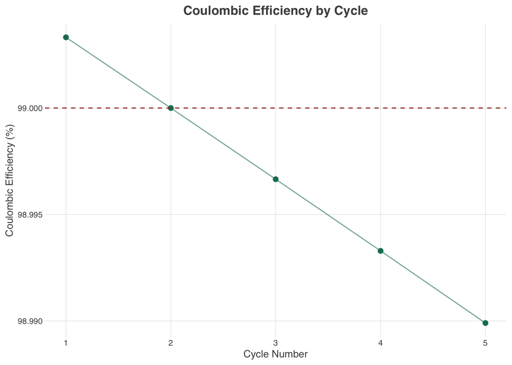

```r
plot_cycling(cycling_data)
```

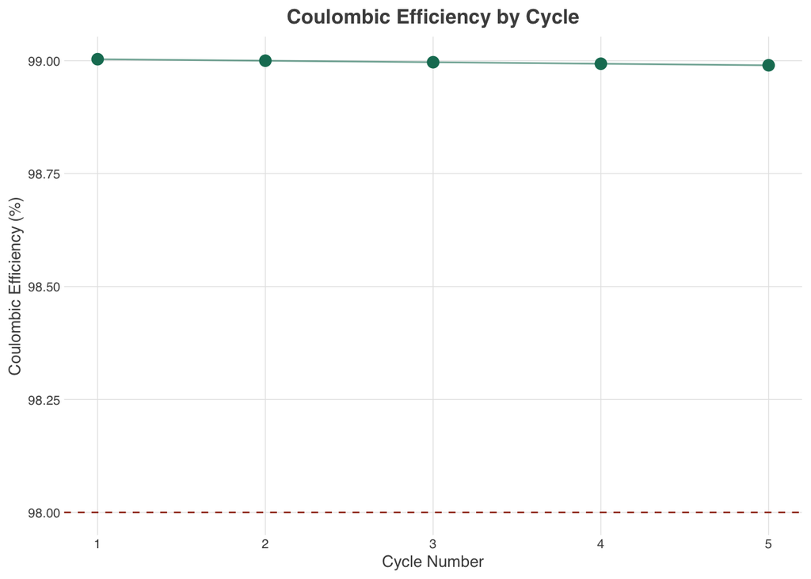

```r
plot_cycling(cycling_data, point_size = 3, ce_threshold = 98)
```

**TipTeaching cue**

Ask students which parts are fixed and which parts are flexible.

- Fixed: the columns, title, geoms, and overall style.
- Flexible: point size, font size, and CE threshold.

Then say:

“Your advisor asks you to change the threshold line from 99 percent to 98 percent across all 15 cycling plots in your thesis. Without the function: find and edit 15 plot blocks. With the function: change one default argument. Done.”

# Segment 8 - Synthesis and bridge to activity (5 min)

**NoteFormer slide 16: bridge to Thursday activity**

“Thursday’s activity walks you through a set of exercises from the NCEAS textbook - s18 in your course website. The exercises use a function called `find_max()` that you will build from scratch, break intentionally, and then harden with the exact same `stop()` and `warning()` patterns we used today.”

Today’s lecture maps to the activity this way:

- `double_it()` and `exclaim_age()` review Monday’s function anatomy.
- `find_max()` with conditionals reviews today’s `if`/`else` pattern.
- Adding `stop()` to `find_max()` follows the same pattern as `calc_specific_capacity()`.
- The default argument `equal_ok = FALSE` follows the same pattern as `gc_min`, `gc_max`, and `ce_threshold`.

“Everything from this week maps directly onto the activity. Keep this file open as a reference. The textbook page s18 has the full exercise set.”

```r
# Function anatomy review.
double_it <- function(x) {
  return(2 * x)
}

exclaim_age <- function(age) {
  return(paste("I am", age, "years old!"))
}

# Conditionals.
find_max <- function(value_1, value_2) {
  if (value_1 > value_2) {
    return(value_1)
  } else if (value_2 > value_1) {
    return(value_2)
  }
}

# Add validation.
find_max <- function(value_1, value_2) {
  if (!is.numeric(value_1) | !is.numeric(value_2)) {
    stop("Values must be numeric.")
  }

  if (value_1 == value_2) {
    stop("Values must be different from each other.")
  }

  if (value_1 > value_2) return(value_1)
  if (value_2 > value_1) return(value_2)
}

# Add a default argument.
find_max <- function(value_1, value_2, equal_ok = FALSE) {
  if (!is.numeric(value_1) | !is.numeric(value_2)) {
    stop("Values must be numeric.")
  }

  if (value_1 == value_2) {
    if (equal_ok) return(value_1)
    stop("Values must be different from each other.")
  }

  if (value_1 > value_2) return(value_1)
  if (value_2 > value_1) return(value_2)
}
```

# Segment 9 - Wrap-up (2 min)

**NoteFormer slide 17: summary**

“The complete function toolkit is now in your hands. Write it once. Protect it with `stop()` and `warning()`. Make it flexible with default arguments. Apply it everywhere, including inside `ggplot`. That’s reproducible, defensible, reusable science.”

Today we added:

- conditionals: `if`, `else if`, and `else`;
- hard errors: `stop()`;
- soft warnings: `warning()`;
- default arguments;
- functions that call other functions;
- plotting functions.

The central judgment is this: would a bad input create a result that could mislead someone? If yes, stop. If the result is suspicious but still worth seeing, warn.

```r
# Today's main functions.
classify_temp()
calc_specific_capacity()
calc_primer_quality()
custom_theme()
plot_cycling()
```

# Exit ticket (1 minute)

**TipBefore you leave**

Copy this into chat or Canvas and fill in the blanks:

**One tool I can use from today:** `stop()` / `warning()` / default arguments / ggplot function

**One thing I want to remember:** ______________________________

**NoteTeaching cue**

Keep this deliberately easy. The goal is not to grade them; it is to give students a tiny retrieval practice moment and give you a quick read on what stuck.